# Task 8_chromosome and protein dataset

Angela Jennifer Tantry

2026-11-01

To perform this task, the tidybiology package is installed and loaded.

```r
# Load the package
library(tidybiology)
library(tidyverse)
```

# a. Summary statistics (mean, median, and maximum) from ‘chromosome’ data

Summary statistics for chromosome data is obtained using the following script:

```r
# Obtain mean, median, and maximum
chromosome_summary <- chromosome %>%
  summarise(
    across(       # apply function across selected columns
      c(variations, protein_codinggenes, mi_rna), # tell columns to perform the function on
    list(               # instruct functions to be run
      mean = mean,
      median = median,
      maximum = max
      )
    )
  )
print(chromosome_summary, width = Inf)
```

```
## # A tibble: 1 × 9
##   variations_mean variations_median variations_maximum protein_codinggenes_mean
##             <dbl>             <dbl>              <dbl>                    <dbl>
## 1        6484572.           6172346           12945965                     850.
##   protein_codinggenes_median protein_codinggenes_maximum mi_rna_mean
##                        <dbl>                       <int>       <dbl>
## 1                        836                        2058        73.2
##   mi_rna_median mi_rna_maximum
##           <dbl>          <int>
## 1            75            134
```

# b. Chromosome size distribution and plot

First, the chromosome size distribution plot is made based on the number of base pairs:

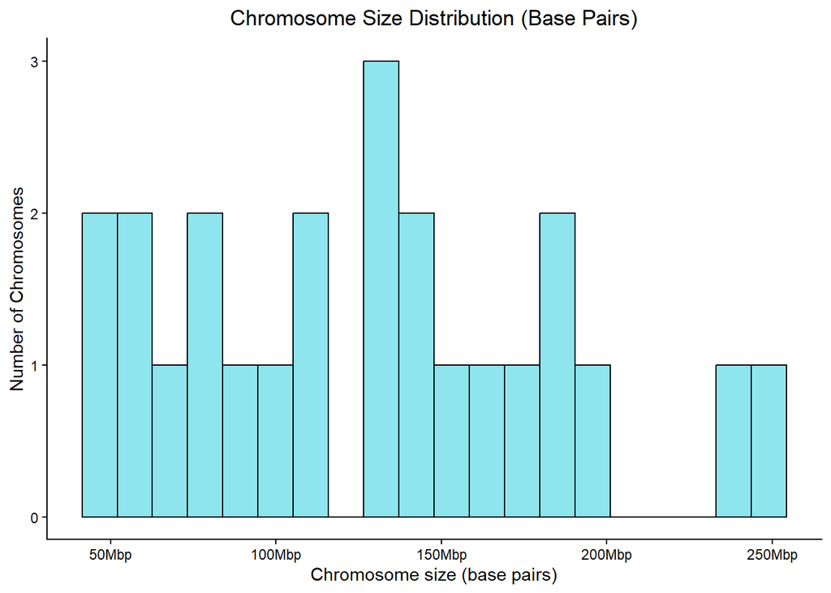

```r
# Make the plot using base pairs data
ggplot(chromosome,
  aes(x = basepairs)) +
  geom_histogram(
    bins = 20,
    fill = "cadetblue2",
    color = "black"
  ) +
  labs(
    title = "Chromosome Size Distribution (Base Pairs)",
    x = "Chromosome size (base pairs)",
    y = "Number of Chromosomes"
  ) +
  scale_x_continuous(
    labels = scales::label_number(scale = 1e-6, suffix = "Mbp") # adjust x axis to Mbp
  ) +
  theme_classic() +
  theme(plot.title = element_text(hjust = 0.5))
```

Based on the plot, the chromosome size based on the base pairs seem to have relatively broad distribution. Most chromosomes are small to medium sized.

Second, the chromosome size distribution plot is made based on the length in millimeters:

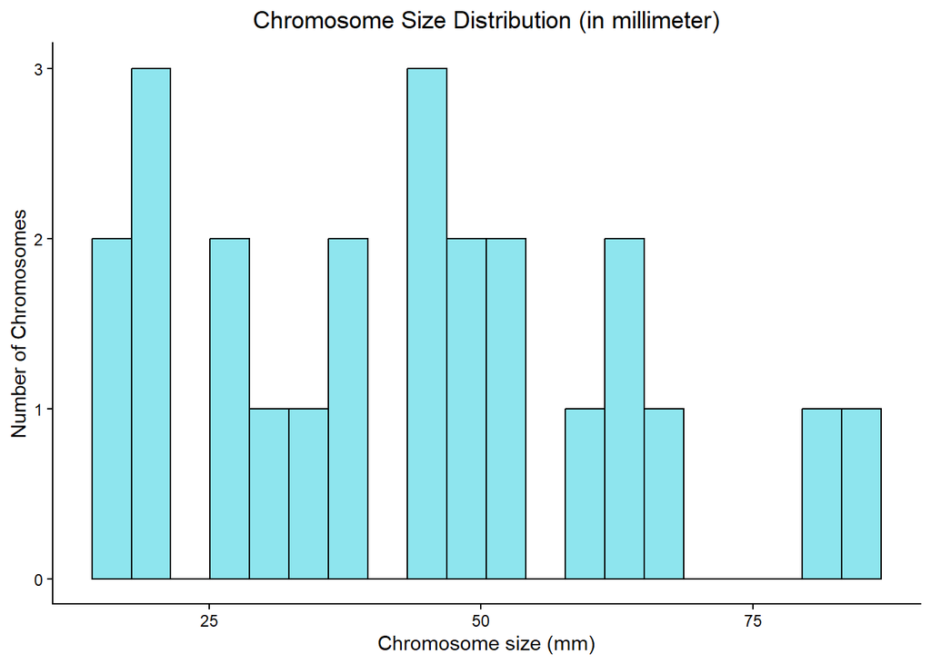

```r
# Make the plot using length_mm data
ggplot(chromosome,
  aes(x = length_mm)) +
  geom_histogram(
    bins = 20,
    fill = "cadetblue2",
    color = "black"
  ) +
  labs(
    title = "Chromosome Size Distribution (in millimeter)",
    x = "Chromosome size (mm)",
    y = "Number of Chromosomes"
  ) +
  theme_classic() +
  theme(plot.title = element_text(hjust = 0.5))
```

In contrast, distribution of chromosome size based on the chromosome length in millimeters seem to be less clear visually.

Therefore, chromosome length in base pairs will be used to address the next question.

# c. Relationships between protein coding genes or miRNAs with the length of the chromosome

First, to explore the relationship between protein coding genes with the length of the chromosome, the following plot is made:

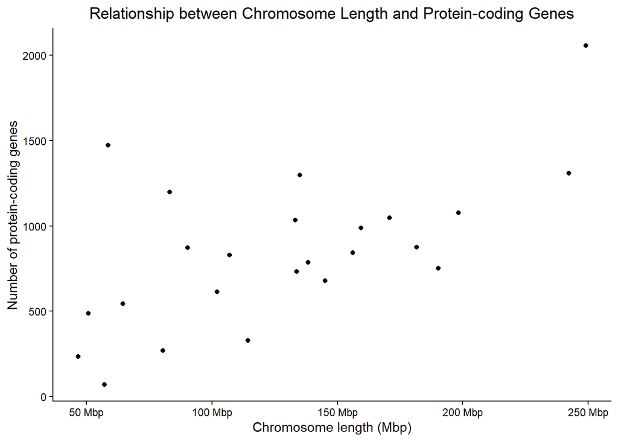

```r
# Make the plot for length vs. protein-coding genes
ggplot(chromosome, aes(
  x = basepairs,
  y = protein_codinggenes
  )) +
  geom_point() +
  labs(
    title = "Relationship between Chromosome Length and Protein-coding Genes",
    x = "Chromosome length (Mbp)",
    y = "Number of protein-coding genes"
  ) +
  scale_x_continuous(
    labels = scales::label_number(scale = 1e-6, suffix = " Mbp") # adjust x axis to Mbp
  ) +
  theme_classic() +
  theme(plot.title = element_text(hjust = 0.5))
```

Based on the plot, the number of protein coding genes generally increase along with the chromosome length, indicating a positive correlation.

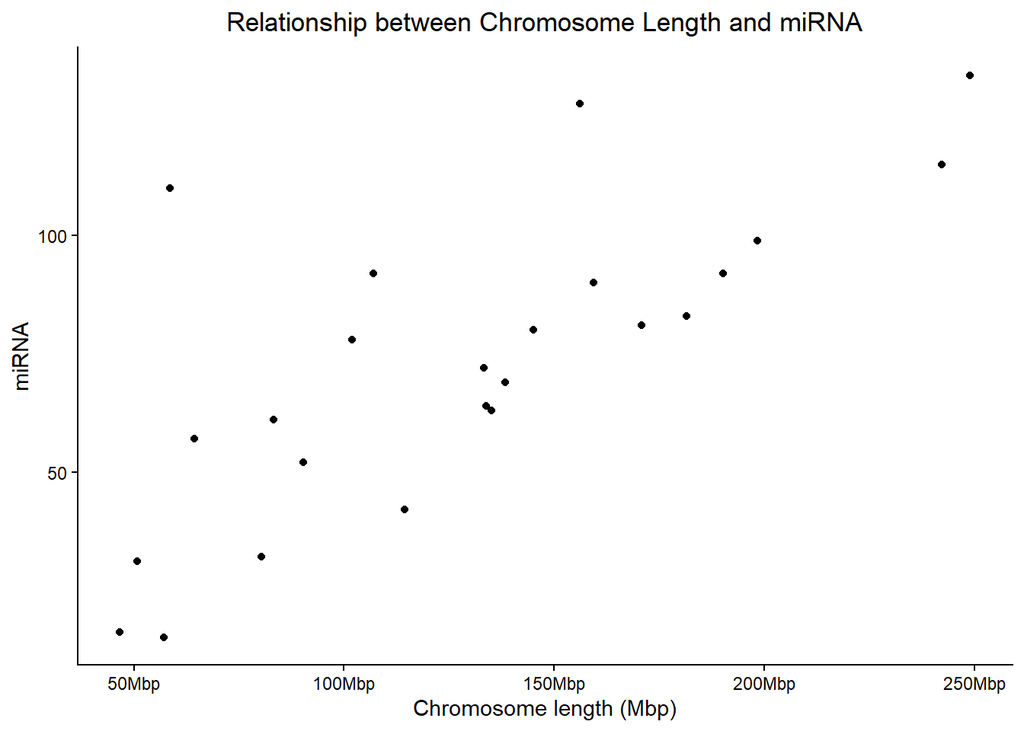

```r
# Make the plot for length vs. miRNA
ggplot(chromosome, aes(
  x = basepairs,
  y = mi_rna
  )) +
  geom_point() +
  labs(
    title = "Relationship between Chromosome Length and miRNA",
    x = "Chromosome length (Mbp)",
    y = "miRNA"
  ) +
  scale_x_continuous(
    labels = scales::label_number(scale = 1e-6, suffix = "Mbp") # adjust x axis to Mbp
  ) +
  theme_classic() +
  theme(plot.title = element_text(hjust = 0.5))
```

Based on the plot, the number of miRNA also increased along with the chromosome length, also indicating a positive correlation.

To further confirm the correlation between chromosome length and protein-coding genes, as well as chromosome length and miRNA, Pearson’s correlation coefficient can be used:

```r
cor(chromosome$basepairs, chromosome$protein_codinggenes)
```

```
## [1] 0.6092793
```

```r
cor(chromosome$basepairs, chromosome$mi_rna)
```

```
## [1] 0.7399229
```

Both results in a positive value, suggesting that longer chromosome tend to contain more protein-coding genes and miRNA.

# d. Summary statistics and visualization for length and mass from ‘proteins’ data

Summary statistics for length and mass data

```r
# Obtain mean, median, and maximum
proteins_summary <- proteins %>%
  summarise(
    across(
      c(length, mass),
      list(
      mean = mean,
      median = median,
      maximum = max
      )
    )
  )
print(proteins_summary, width = Inf)
```

```
## # A tibble: 1 × 6
##   length_mean length_median length_maximum mass_mean mass_median mass_maximum
##         <dbl>         <dbl>          <dbl>     <dbl>       <dbl>        <dbl>
## 1        557.           414          34350    62061.      46140.      3816030
```

Visualization of the relationship between length and mass by utilizing the ggplot2 package functions

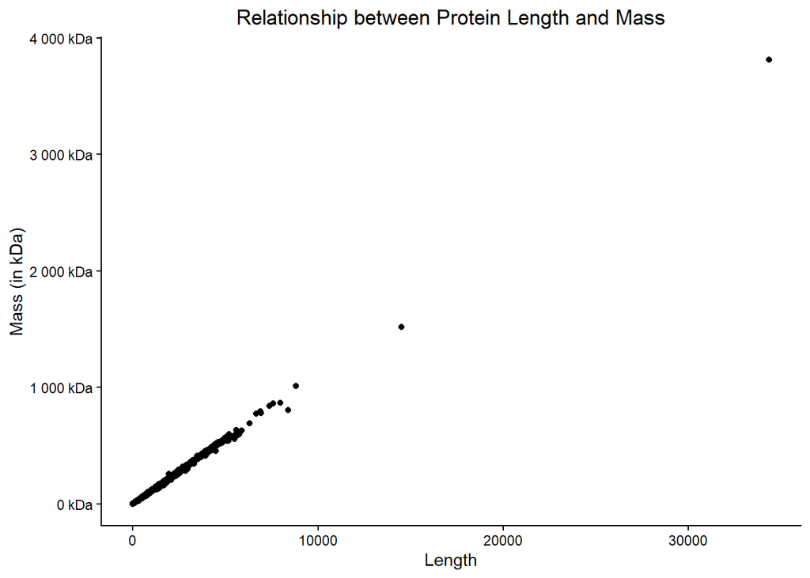

```r
# Make the plot
ggplot(proteins, aes(
  x = length,
  y = mass)) +
  geom_point() +
  labs(
    title = "Relationship between Protein Length and Mass",
    x = "Length",
    y = "Mass (in kDa)"
  ) +
  scale_y_continuous(
  labels = scales::label_number(scale = 1e-3, suffix = " kDa")  # adjust y axis to kDa
  ) +
  theme_classic() +
  theme(plot.title = element_text(hjust = 0.5))
```

To make the relationship clearer, the visualization can also be made in logarithmic scale with the following script:

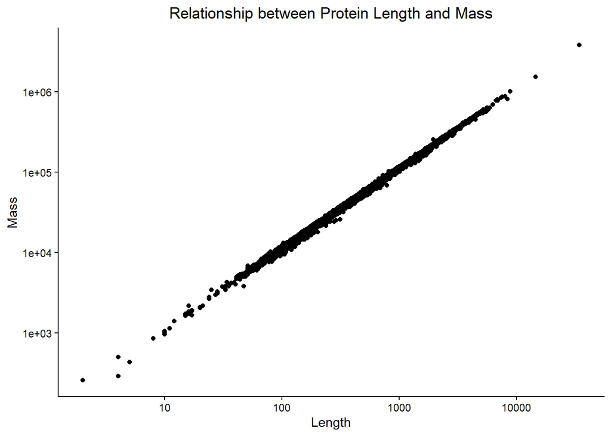

```r
   ggplot(proteins, aes(
  x = length,
  y = mass)) +
  geom_point() +
  labs(
    title = "Relationship between Protein Length and Mass",
    x = "Length",
    y = "Mass"
  ) +
  scale_x_log10() +      # logarithmic scaling to x axis
  scale_y_log10() +      # logarithmic scaling to y axis
  theme_classic() +
  theme(plot.title = element_text(hjust = 0.5))
```

Based on the plot, the length and mass of proteins have positive correlation. Longer proteins generally have higher molecular mass. The relationship also appears to be linear on the log-log scale.